# M3 Draft: Public Health Agency of Canada Surveillance Data: Trends in Apparent Opioid Toxicity Death Rates and Male-to-Female Rate Ratios Across Canada’s Provinces and Territories, 2016–2025

Descriptive project update for provincial and regional public-health readers

## Purpose and audience

This draft is for provincial and regional public-health decision makers. It summarizes PHAC’s published rates and highlights patterns that may need local follow-up. It does not explain causes or evaluate policies, services, or funding decisions.

## Question

How did PHAC’s published crude annual rates of apparent opioid toxicity deaths vary across Canada’s provinces and territories from 2016 to 2025? When both male and female rates are available, how did the male-to-female rate ratio vary?

## Data source and provenance

The analysis uses PHAC’s public *Opioid- and Stimulant-related Harms in Canada* release. We use the September 22, 2026 CSV snapshot, accessed October 26, 2026. PHAC’s [technical notes](https://health-infobase.canada.ca/substance-related-harms/opioids-stimulants/technical-notes.html) describe the definitions, reporting changes, and coverage. The data are aggregate surveillance values, not individual records.

## Setup

The fixed source file is `data/SubstanceHarmsData.csv`. Each analysis record represents one jurisdiction in one year, not a person or a death. We select annual crude rates for opioid deaths from 2016 through 2025, including overall rates and rates reported for males and females. Crude rates are not adjusted for age. We exclude quarterly data, partial 2026 data, and records about other substances. Canada is PHAC’s national reference series, not an additional province or territory.

```r
# AI prompt: Read the PHAC CSV as text using repository-relative paths.
# Select annual opioid-death crude rates for 2016-2025 and reshape overall,
# male, and female values into unique region-years. Preserve zeroes and
# suppression labels, calculate ratios only with a positive female denominator,
# and flag partial-year coverage and the specified 2025 reporting changes.
# Verified: Checked source filters, unique keys, numeric values, zeroes, and raw suppression labels.
# M3 revision prompt summary: output-path change only.
# AI prompt: Keep the M2 data preparation unchanged, but write its generated
# CSV outputs under milestones/m3-project-update/submission/outputs.
# Verified: Compared this chunk with M2; only out_dir changed. Confirmed the
# fixed CSV hash and generated M3 CSV outputs after rendering.

library(readr)
library(dplyr)
library(tidyr)
library(knitr)
library(ggplot2)

roots <- c(".", "../../..")
repo_root <- roots[file.exists(file.path(roots, "data/SubstanceHarmsData.csv"))][1]

if (is.na(repo_root)) stop("Cannot find data/SubstanceHarmsData.csv.")

out_dir <- file.path(repo_root, "milestones/m3-project-update/submission/outputs")
dir.create(out_dir, recursive = TRUE, showWarnings = FALSE)

source_df <- read_csv(
  file.path(repo_root, "data/SubstanceHarmsData.csv"),
  col_types = cols(.default = col_character()),
  na = character()
)

selected <- source_df |>
  filter(
    Substance == "Opioids",
    Source == "Deaths",
    Time_Period == "By year",
    Year_Quarter %in% as.character(2016:2025),
    Unit == "Crude rate",
    (Specific_Measure == "Overall numbers" & Disaggregator == "") |
      (Specific_Measure == "Sex" & Disaggregator %in% c("Male", "Female"))
  ) |>
  transmute(
    Region,
    Year = as.integer(Year_Quarter),
    measure = case_when(
      Specific_Measure == "Overall numbers" ~ "overall",
      Disaggregator == "Male" ~ "male",
      TRUE ~ "female"
    ),
    raw = trimws(Value)
  )

stopifnot(!anyDuplicated(selected[c("Region", "Year", "measure")]))

is_numeric <- grepl("^[0-9]+([.][0-9]+)?$", selected$raw)

selected$rate <- NA_real_
selected$rate[is_numeric] <- as.numeric(selected$raw[is_numeric])

selected$status <- case_when(
  is_numeric ~ "Reported",
  selected$raw == "Suppr." ~ "Suppressed",
  selected$raw == "n/a" ~ "Unavailable",
  TRUE ~ "Unexpected"
)

stopifnot(!any(selected$status == "Unexpected"))

panel <- selected |>
  pivot_wider(
    names_from = measure,
    values_from = c(raw, rate, status),
    names_glue = "{measure}_{.value}"
  ) |>
  mutate(
    partial_year = Region == "Nunavut" & Year == 2023,
    definition_change =
      Region %in% c("British Columbia", "Quebec", "Canada") & Year == 2025,
    ratio_rate = if_else(
      !is.na(male_rate) & !is.na(female_rate) & female_rate > 0,
      male_rate / female_rate,
      NA_real_
    ),
    ratio_status = case_when(
      male_status == "Suppressed" |
        female_status == "Suppressed" ~ "Suppressed",
      male_status == "Unavailable" |
        female_status == "Unavailable" ~ "Unavailable",
      female_rate == 0 ~ "Zero denominator",
      !is.na(ratio_rate) ~ "Reported",
      TRUE ~ "Unexpected"
    )
  ) |>
  arrange(Region, Year)

stopifnot(!anyDuplicated(panel[c("Region", "Year")]))
stopifnot(nrow(panel) == 140, n_distinct(panel$Region) == 14)

kable(
  data.frame(
    Step = c(
      "Source CSV rows",
      "Selected rate records",
      "Unique region-years"
    ),
    N = c(nrow(source_df), nrow(selected), nrow(panel))
  ),
  caption = "Selection flow: three rate records (overall, male, and female) form one jurisdiction-year."
)
```

Selection flow: three rate records (overall, male, and female) form one jurisdiction-year.

| Step | N |
| --- | --- |
| Source CSV rows | 33250 |
| Selected rate records | 420 |
| Unique region-years | 140 |

## Methods: selection and exclusions

The inclusion rules and exceptions below were set before interpreting the figures.

## Cohort

Table 1 uses the same calendar years, 2016–2024, for every jurisdiction. We leave 2025 out of the table because PHAC notes reporting changes for British Columbia, Quebec, and Canada that year. We still show 2025 in the availability audit, endpoint table, and annual figures, with a caution. These 2025 values are not a like-for-like continuation of earlier years. In British Columbia, overall data include ongoing investigations involving all unregulated drugs, while sex-specific data cover completed opioid-toxicity investigations. Quebec’s 2025 data include presumed drug poisonings still under investigation. We also exclude Nunavut 2023 because it covers only part of the year. Even with a common time window, some values are suppressed or unavailable; Table 1 shows the number of contributing years in each cell.

```r
# M3 revision prompt summary, based on the M2 feedback.
# AI prompt: Revise the M2 summary-eligibility chunk to use the same
# 2016-2024 calendar window for every region after checking data availability.
# Exclude partial-year Nunavut 2023, retain all 2016-2025 rows in the
# availability audit and figures, and display the Table 1 selection counts.
# Verified: Checked 126 region-years in 2016-2024 before the Nunavut
# exclusion, 125 afterward, and the 2025 and Nunavut cautions against
# the source data and PHAC technical notes.

summary_df <- panel |>
  filter(Year <= 2024, !partial_year)

kable(
  data.frame(
    Step = c(
      "Selected region-years",
      "2025 rows outside common window",
      "Partial-year Nunavut 2023 exclusion",
      "Table 1 region-years"
    ),
    N = c(
      nrow(panel),
      sum(panel$Year == 2025),
      sum(panel$partial_year),
      nrow(summary_df)
    )
  ),
  caption = "The 2016–2025 panel remains available for the audit and annual figures."
)
```

The 2016–2025 panel remains available for the audit and annual figures.

| Step | N |
| --- | --- |
| Selected region-years | 140 |
| 2025 rows outside common window | 14 |
| Partial-year Nunavut 2023 exclusion | 1 |
| Table 1 region-years | 125 |

## Missingness

We keep suppressed and unavailable values missing; we do not treat them as zero or estimate them. A published zero remains zero. We calculate a male-to-female ratio only when both rates are reported and the female rate is above zero. Because PHAC publishes rounded rates, the ratios are approximate. The availability summary covers all 140 selected jurisdiction-years, including 2025 and years later excluded from Table 1. We do not know whether years with missing values differ systematically from years with reported values, so the summaries describe only the available data.

```r
# AI prompt: Before exclusions, summarize availability of overall, male, female,
# and ratio values across all selected region-years. Include numeric and missing
# counts, missing percentages, and separate counts for suppression, unavailable
# values, and zero denominators. Display and export missingness-summary.csv.
# Verified: Compared all availability categories and percentages with separate base-R counts and the exported CSV.

measures <- c("overall", "male", "female", "ratio")

missingness <- bind_rows(lapply(measures, function(m) {
  v <- panel[[paste0(m, "_rate")]]
  s <- panel[[paste0(m, "_status")]]

  data.frame(
    Measure = m,
    Region_year_N = nrow(panel),
    Numeric_N = sum(!is.na(v)),
    Missing_N = sum(is.na(v)),
    Missing_percent = round(100 * mean(is.na(v)), 1),
    Suppressed_N = sum(s == "Suppressed"),
    Unavailable_N = sum(s == "Unavailable"),
    Zero_denominator_N = sum(s == "Zero denominator")
  )
}))

write_csv(missingness, file.path(out_dir, "missingness-summary.csv"))

kable(
  missingness,
  caption = "Availability before summary exclusions; N counts region-years."
)
```

Availability before summary exclusions; N counts region-years.

| Measure | Region_year_N | Numeric_N | Missing_N | Missing_percent | Suppressed_N | Unavailable_N | Zero_denominator_N |
| --- | --- | --- | --- | --- | --- | --- | --- |
| overall | 140 | 134 | 6 | 4.3 | 4 | 2 | 0 |
| male | 140 | 115 | 25 | 17.9 | 23 | 2 | 0 |
| female | 140 | 115 | 25 | 17.9 | 23 | 2 | 0 |
| ratio | 140 | 111 | 29 | 20.7 | 23 | 2 | 4 |

## Table 1: compact regional summary

Table 1 summarizes annual rates available in 2016–2024. Most jurisdictions have nine years of reported data for each measure. In Yukon, both male and female rates are reported in four years; in the Northwest Territories, both are reported in five years. The overall means for these territories use those same years. PHAC suppresses Prince Edward Island’s male and female rates, so no ratio can be calculated. Nunavut has reported full-year overall, male, and female rates only for 2016–2018; all are zero. The female rate of zero means no ratio can be calculated for those years, and the other years have no usable sex-specific rates. An overall rate is published separately and cannot reveal suppressed male or female rates. The `n` in each cell is the number of years included in that summary.

Each cell gives the mean and sample standard deviation (SD) of the available annual values. The SD describes how much those annual values vary. Rates are crude deaths per 100,000 people. The male-to-female ratio is each year’s male rate divided by its female rate; it has no unit and is approximate because PHAC’s published rates are rounded. These are averages of annual rates, not pooled rates for the full period. Canada’s row is PHAC’s national series, not an average of provincial and territorial rates.

```r
# M3 revision prompt summary, based on the M2 feedback.
# AI prompt: Revise the M2 Table 1 chunk into one row per region and four
# columns: overall, female, male, and male-to-female ratio. Use the common
# 2016-2024 window, show mean (sample SD) and contributing-year n in each
# cell, remove year lists, and explain remaining n differences in the
# caption. Retain matched-year overall means for Yukon and the Northwest
# Territories and PEI's independently reported overall series.
# Verified: Audited availability across all 14 regions and four measures;
# independently recalculated all 56 exported table cells from the CSV and
# checked the matched-year counts (Yukon n=4; Northwest Territories n=5).

mean_sd <- function(x) {
  x <- x[!is.na(x)]

  if (!length(x)) return("Not available")

  if (length(x) == 1) {
    return(sprintf("%.2f (SD unavailable)", x))
  }

  sprintf("%.2f (%.2f)", mean(x), sd(x))
}

table1_long <- summary_df |>
  mutate(both_sex_rates_reported = !is.na(male_rate) & !is.na(female_rate)) |>
  select(Region, Year, both_sex_rates_reported, all_of(paste0(measures, "_rate"))) |>
  pivot_longer(
    ends_with("_rate"),
    names_to = "Measure",
    values_to = "Rate"
  ) |>
  mutate(Measure = sub("_rate$", "", Measure)) |>
  filter(
    !(Measure == "overall" & Region %in% c("Yukon", "Northwest Territories")) |
      both_sex_rates_reported
  ) |>
  group_by(Region, Measure) |>
  summarise(
    n = sum(!is.na(Rate)),
    Mean_SD = mean_sd(Rate),
    .groups = "drop"
  ) |>
  mutate(
    Cell = if_else(n == 0, "Not available (n=0)",
                   paste0(Mean_SD, "; n=", n)),
    Measure = recode(
      Measure,
      overall = "Overall",
      female = "Female",
      male = "Male",
      ratio = "Male-to-female ratio"
    )
  )

table1 <- table1_long |>
  select(Region, Measure, Cell) |>
  pivot_wider(names_from = Measure, values_from = Cell) |>
  select(Region, Overall, Female, Male, `Male-to-female ratio`)

write_csv(table1, file.path(out_dir, "table1.csv"))

kable(
  table1,
  caption = "Table 1. Mean (sample SD) of annual values; n = number of contributing years in 2016–2024. Nunavut 2023 is excluded because it covers only part of the year. Yukon and Northwest Territories overall means use only years when both male and female rates are reported (n = 4 and 5), so the measures cover the same years. Other n differences reflect suppressed or unavailable values. Rates are crude deaths per 100,000 people."
)
```

Table 1. Mean (sample SD) of annual values; n = number of contributing years in 2016–2024. Nunavut 2023 is excluded because it covers only part of the year. Yukon and Northwest Territories overall means use only years when both male and female rates are reported (n = 4 and 5), so the measures cover the same years. Other n differences reflect suppressed or unavailable values. Rates are crude deaths per 100,000 people.

| Region | Overall | Female | Male | Male-to-female ratio |
| --- | --- | --- | --- | --- |
| Alberta | 25.23 (9.78); n=9 | 14.06 (6.13); n=9 | 36.23 (13.58); n=9 | 2.63 (0.29); n=9 |
| British Columbia | 30.48 (9.23); n=9 | 12.98 (4.61); n=9 | 48.28 (14.16); n=9 | 3.82 (0.52); n=9 |
| Canada | 14.54 (4.71); n=9 | 7.86 (2.47); n=9 | 21.19 (6.95); n=9 | 2.69 (0.21); n=9 |
| Manitoba | 15.07 (8.60); n=9 | 11.57 (6.65); n=9 | 18.49 (10.61); n=9 | 1.61 (0.30); n=9 |
| New Brunswick | 6.79 (2.94); n=9 | 5.57 (1.52); n=9 | 8.07 (4.62); n=9 | 1.38 (0.53); n=9 |
| Newfoundland and Labrador | 5.29 (1.73); n=9 | 4.29 (1.80); n=9 | 6.32 (1.91); n=9 | 1.61 (0.50); n=9 |
| Northwest Territories | 11.62 (3.97); n=5 | 9.16 (4.55); n=5 | 13.92 (5.63); n=5 | 1.93 (1.35); n=5 |
| Nova Scotia | 5.77 (0.88); n=9 | 3.61 (0.70); n=9 | 7.99 (1.44); n=9 | 2.26 (0.50); n=9 |
| Nunavut | 0.00 (0.00); n=3 | 0.00 (0.00); n=3 | 0.00 (0.00); n=3 | Not available (n=0) |
| Ontario | 13.37 (4.44); n=9 | 7.19 (2.01); n=9 | 19.66 (6.89); n=9 | 2.68 (0.28); n=9 |
| Prince Edward Island | 4.41 (1.35); n=9 | Not available (n=0) | Not available (n=0) | Not available (n=0) |
| Quebec | 3.28 (0.47); n=9 | 2.42 (0.33); n=9 | 4.09 (0.70); n=9 | 1.70 (0.26); n=9 |
| Saskatchewan | 17.76 (9.02); n=9 | 13.44 (6.07); n=9 | 22.03 (11.99); n=9 | 1.56 (0.27); n=9 |
| Yukon | 40.90 (10.15); n=4 | 32.80 (12.91); n=4 | 48.95 (12.42); n=4 | 1.64 (0.61); n=4 |

## Results: annual comparisons

### Endpoint comparison

This table compares PHAC’s published overall crude rates in 2016, 2024, and 2025. Suppressed and unavailable labels remain as published; they are not changed to zero. We flag the 2025 values for British Columbia, Quebec, and Canada because reporting changed. These three years do not show the full path between 2016 and 2025.

```r
# AI prompt: Compare each region's published overall crude rates in 2016,
# 2024, and 2025. Preserve source suppression and unavailable labels and flag
# reporting changes without implying endpoints describe the full trajectory.
# Verified: Compared displayed values with the source CSV and PHAC notes.

endpoints <- panel |>
  filter(Year %in% c(2016, 2024, 2025)) |>
  select(Region, Year, overall_raw) |>
  pivot_wider(
    names_from = Year,
    values_from = overall_raw,
    names_prefix = "Rate_"
  )

kable(
  endpoints,
  caption = "Published overall crude rates per 100,000; 2025 reporting changes are flagged in the text."
)
```

Published overall crude rates per 100,000; 2025 reporting changes are flagged in the text.

| Region | Rate_2016 | Rate_2024 | Rate_2025 |
| --- | --- | --- | --- |
| Alberta | 14.3 | 24.4 | 22.9 |
| British Columbia | 16.6 | 35.7 | 32.6 |
| Canada | 7.8 | 16.2 | 13.7 |
| Manitoba | 6.7 | 25.0 | 15.3 |
| New Brunswick | 4.5 | 10.0 | 9.9 |
| Newfoundland and Labrador | 3.4 | 8.6 | 4.9 |
| Northwest Territories | 11.2 | 15.5 | 4.4 |
| Nova Scotia | 5.6 | 6.2 | 7.0 |
| Nunavut | 0.0 | n/a | n/a |
| Ontario | 6.2 | 14.0 | 8.7 |
| Prince Edward Island | 3.4 | 4.5 | 7.1 |
| Quebec | 3.2 | 3.4 | 6.5 |
| Saskatchewan | 7.3 | 21.8 | 18.7 |
| Yukon | 18.2 | 29.4 | 29.0 |

PHAC reported a Canada crude rate of 7.8 deaths per 100,000 people in 2016 and 16.2 in 2024. The rate was higher at the 2024 endpoint, but these two values do not show whether it increased every year or explain why it changed. The annual figure shows the intervening years. The 2025 Canada value is also shown with a reporting-change caution. Table 1 summarizes male-to-female ratios only when both rates are available and the female rate is above zero. A missing ratio does not mean the rates were equal.

### Figure 1: annual reported crude death rates

Each panel shows one province or territory in blue; the grey line shows PHAC’s Canada reference rate. The panels share a vertical scale that starts at zero. Nunavut 2023 is omitted because it covers only part of the year. Triangles mark 2025 values with reporting cautions for British Columbia, Quebec, and Canada. Those points are not connected to earlier years, so the chart does not suggest they are directly comparable.

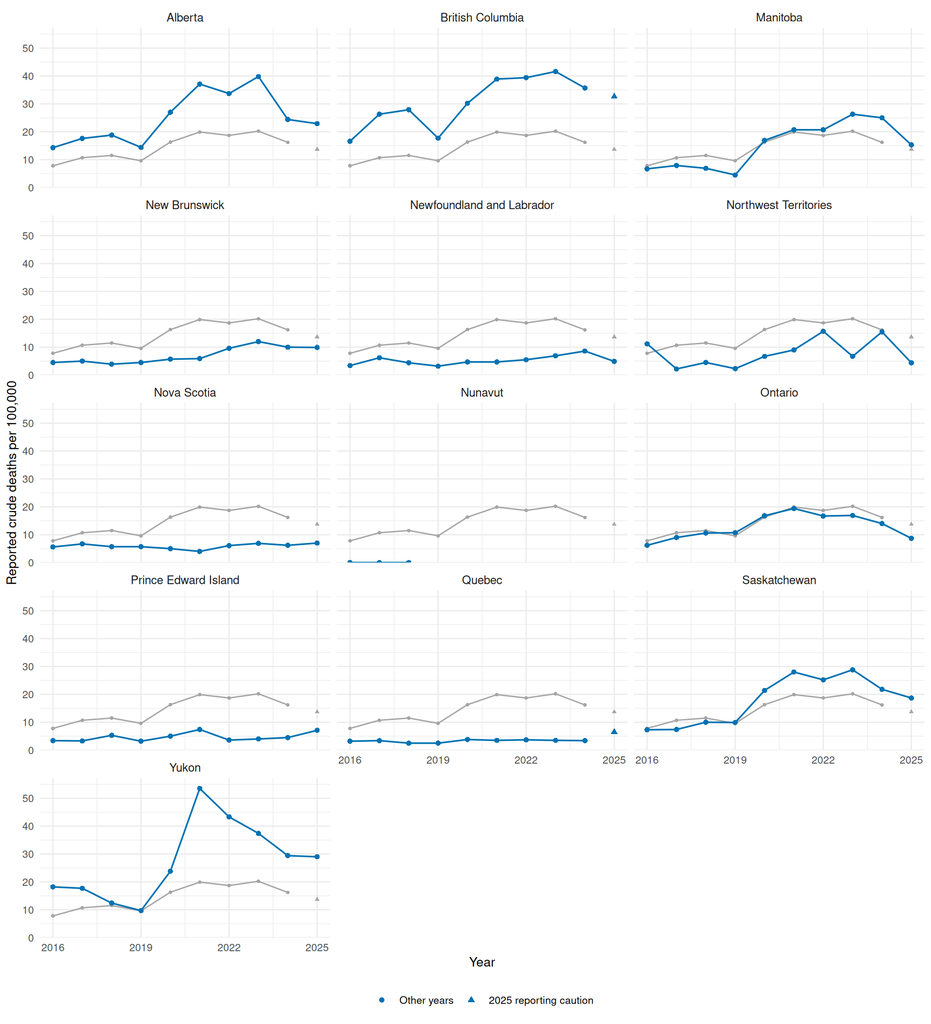

PHAC’s annual published crude rates of apparent opioid toxicity deaths per 100,000 people. Blue: province or territory; grey: Canada reference. Gaps indicate suppressed, unavailable, or excluded partial-year data. Triangles mark 2025 reporting cautions.

```r
# AI prompt: Follow our M1 plan with one panel per province or territory,
# blue annual crude-rate trends, and a grey PHAC Canada reference. Preserve gaps,
# omit partial-year Nunavut 2023, and show flagged 2025 values as disconnected
# triangles. Use common zero-based axes and explain colours and markers.
# Verified: Checked plotted values against source rates and confirmed partial-year omissions and disconnected caution points.

plot_panel <- panel |>
  mutate(
    plot_rate = if_else(partial_year, NA_real_, overall_rate),
    line_rate = if_else(definition_change, NA_real_, plot_rate),
    plot_ratio = if_else(partial_year, NA_real_, ratio_rate),
    line_ratio = if_else(definition_change, NA_real_, plot_ratio)
  )

jurisdictions <- plot_panel |>
  filter(Region != "Canada")

canada_reference <- plot_panel |>
  filter(Region == "Canada") |>
  select(-Region)

ggplot(jurisdictions, aes(x = Year)) +
  geom_line(
    data = canada_reference,
    aes(y = line_rate),
    colour = "grey65",
    linewidth = 0.5,
    na.rm = TRUE
  ) +
  geom_point(
    data = canada_reference,
    aes(y = plot_rate, shape = definition_change),
    colour = "grey65",
    size = 1,
    na.rm = TRUE
  ) +
  geom_line(
    aes(y = line_rate),
    colour = "#0072B2",
    linewidth = 0.6,
    na.rm = TRUE
  ) +
  geom_point(
    aes(y = plot_rate, shape = definition_change),
    colour = "#0072B2",
    size = 1.6,
    na.rm = TRUE
  ) +
  facet_wrap(~Region, ncol = 3) +
  scale_shape_manual(
    values = c("FALSE" = 16, "TRUE" = 17),
    labels = c("Other years", "2025 reporting caution")
  ) +
  scale_x_continuous(breaks = c(2016, 2019, 2022, 2025)) +
  scale_y_continuous(
    limits = c(0, NA),
    expand = expansion(mult = c(0, 0.07))
  ) +
  labs(
    x = "Year",
    y = "Reported crude deaths per 100,000",
    shape = NULL
  ) +
  theme_minimal(base_size = 10) +
  theme(
    legend.position = "bottom",
    strip.text = element_text(size = 9)
  )
```

### Figure 2: male-to-female rate ratios

A ratio above 1 means the reported male rate is higher than the female rate. We do not calculate a ratio if either rate is suppressed or unavailable, or if the female rate is zero. No ratio is available for Prince Edward Island or Nunavut in this release. The 2025 values with reporting cautions are shown separately here as well.

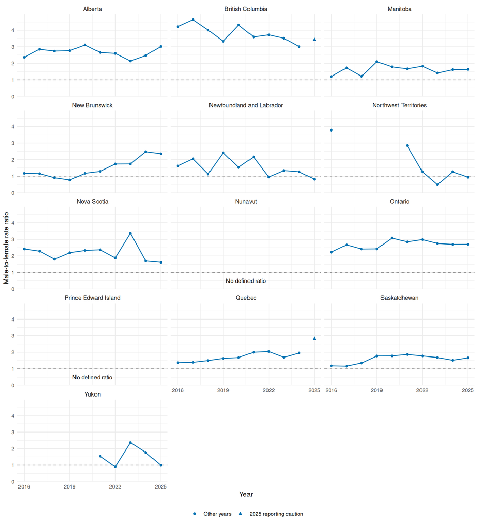

Male-to-female ratios calculated from PHAC’s rounded crude rates. The dashed line marks equal reported rates. Gaps and missing ratios do not mean the rates were equal. PHAC’s reported sex categories are not measures of gender identity.

```r
# AI prompt: Plot annual male-to-female rate ratios by province or territory
# using common zero-based axes and a dashed reference at 1. Preserve gaps and
# disconnected flagged 2025 points, label panels with no defined ratios, and
# explain that missing ratios do not imply equality or describe gender identity.
# Verified: Checked ratios against male and female rates, positive denominators, missing-data gaps, and empty-panel labels.

no_ratio <- jurisdictions |>
  group_by(Region) |>
  summarise(
    no_values = all(is.na(plot_ratio)),
    .groups = "drop"
  ) |>
  filter(no_values)

ggplot(jurisdictions, aes(x = Year)) +
  geom_hline(
    yintercept = 1,
    linetype = "dashed",
    colour = "grey55"
  ) +
  geom_line(
    aes(y = line_ratio),
    colour = "#0072B2",
    linewidth = 0.6,
    na.rm = TRUE
  ) +
  geom_point(
    aes(y = plot_ratio, shape = definition_change),
    colour = "#0072B2",
    size = 1.6,
    na.rm = TRUE
  ) +
  geom_text(
    data = no_ratio,
    aes(x = 2020.5, y = 0.5),
    label = "No defined ratio",
    inherit.aes = FALSE,
    size = 3
  ) +
  facet_wrap(~Region, ncol = 3) +
  scale_shape_manual(
    values = c("FALSE" = 16, "TRUE" = 17),
    labels = c("Other years", "2025 reporting caution")
  ) +
  scale_x_continuous(breaks = c(2016, 2019, 2022, 2025)) +
  scale_y_continuous(
    limits = c(0, NA),
    expand = expansion(mult = c(0, 0.07))
  ) +
  labs(
    x = "Year",
    y = "Male-to-female rate ratio",
    shape = NULL
  ) +
  theme_minimal(base_size = 10) +
  theme(
    legend.position = "bottom",
    strip.text = element_text(size = 9)
  )
```

### Interpretation, limitations, and stewardship

This is a descriptive analysis, not a causal study. PHAC’s crude rates are not adjusted for age. Comparisons can also be affected by population size, reporting coverage, investigations that are still underway, and changes in how deaths are counted.

PHAC’s reported male and female categories are not the same as gender identity. We leave suppressed values missing; we do not estimate hidden counts or identify individuals. These results can help identify questions for further study, but they do not explain causes or show which policy response would work.

Source: [PHAC surveillance release](https://health-infobase.canada.ca/substance-related-harms/opioids-stimulants/).

Coverage and reporting cautions: [PHAC technical notes](https://health-infobase.canada.ca/substance-related-harms/opioids-stimulants/technical-notes.html).

## What the current evidence means for the audience

The main finding is that PHAC reported a higher Canada crude rate in 2024 than in 2016 (16.2 versus 7.8 deaths per 100,000 people). The panels show that reported rates and data availability vary across jurisdictions. For a briefing, the figures can help identify patterns for local review alongside information about age structure and reporting practices. They cannot explain causes or be used to rank services.

We need feedback on whether the 13 province-and-territory panels and the Canada reference are easy to read, and whether the 2025 cautions are prominent enough. The male-to-female figure is secondary because some jurisdictions have no ratio that can be calculated from the published data.

## Limitations and next step

The rates are crude and are not adjusted for age. Comparisons may also reflect population size, differences in how deaths are classified, investigation delays, or reporting coverage. Recent values may change as investigations are completed. We keep suppressed or unavailable values missing. Ratios use rounded source rates and are shown only when both rates are available and the female rate is above zero. PHAC’s reported male and female categories are not measures of gender identity. We will use peer feedback to improve the figures and the placement of cautions before finalizing the knowledge-translation product.

## Reproducibility and AI audit

To recreate the report, run `quarto render milestones/m3-project-update/submission/report-draft.qmd` from the repository root. The source reads the fixed CSV at `data/SubstanceHarmsData.csv` and generates the tables, figures, and two CSV outputs. The M2 submission documents the analysis methods; the M3 AI-use note describes AI assistance and how this draft was checked.

## Source

Public Health Agency of Canada. [Opioid- and Stimulant-related Harms in Canada](https://health-infobase.canada.ca/substance-related-harms/opioids-stimulants/). September 22, 2026 snapshot accessed October 26, 2026. [Technical notes](https://health-infobase.canada.ca/substance-related-harms/opioids-stimulants/technical-notes.html).